# Healthcare Investment and Global Disease Burden: A Cross-Country Analysis

Khushi Amit Desai

2026-07-19

# 1 Introduction

Access to healthcare resources varies dramatically across countries. While some nations spend over $9,000 per person on healthcare annually, others spend less than $50. This raises a fundamental question for global health policy, pharmaceutical strategy, and health technology investment:

**Does healthcare spending actually reduce disease burden, and if so, which diseases respond most to investment?**

This analysis uses data from the World Bank and the Institute for Health Metrics and Evaluation (IHME) Global Burden of Disease 2023 study to explore the relationship between healthcare expenditure and health outcomes across 150+ countries from 2000 to 2019.

This project was motivated by my research experience in the Baral Lab at Johns Hopkins University, where I work with large-scale multi-country epidemiological datasets.

## 1.1 Research Questions

1. Is there a relationship between healthcare spending per capita and life expectancy?
2. Which diseases show the highest burden across global regions?
3. Does higher healthcare spending reduce disease-specific death rates, and does this differ between infectious and non-communicable diseases?
4. How has life expectancy changed across regions from 2000 to 2019?
5. What is the spending gap between the highest and lowest life expectancy countries?

# 2 Data Sources

| Dataset | Source | Coverage |
| --- | --- | --- |
| Healthcare expenditure per capita (USD) | World Bank | 190+ countries, 2000-2023 |
| Life expectancy at birth (years) | World Bank | 190+ countries, 1960-2022 |
| Hospital beds per 1,000 people | World Bank | 190+ countries, 1960-2022 |
| Disease-specific death rates per 100,000 | IHME GBD 2023 | 190+ countries, 2000-2019 |

Diseases analysed: HIV/AIDS, Tuberculosis, Malaria, Cardiovascular diseases, Neoplasms (cancer), Diabetes mellitus, Lower respiratory infections.

# 3 Data Cleaning and Methodology

```r
merged_full <- read_csv("./data/processed/merged_full.csv",
                        show_col_types = FALSE)

df <- merged_full %>%
  filter(
    !is.na(health_spending_per_capita),
    !is.na(wb_life_expectancy),
    !is.na(region),
    !is.na(cause),
    cause != "NA",
    year %in% c(2000, 2005, 2010, 2015, 2019)
  )

cat("Countries in analysis:", n_distinct(df$country), "\n")
```

```
## Countries in analysis: 192
```

```r
cat("Years covered:", unique(df$year), "\n")
```

```
## Years covered: 2005 2010 2015 2019 2000
```

```r
cat("Diseases analysed:", unique(df$cause), "\n")
```

```
## Diseases analysed: Cardiovascular diseases Neoplasms Diabetes mellitus Total cancers Tuberculosis HIV/AIDS Lower respiratory infections Malaria
```

**Key cleaning steps performed:**

- Reshaped World Bank data from wide format (years as columns) to long format
- Removed regional aggregates (e.g. “Sub-Saharan Africa aggregate”) and kept only individual countries
- Matched countries across datasets using ISO country codes via the `countrycode` R package
- Removed rows with missing values in key variables
- Filtered GBD data to all-ages, both-sex, rate metric for consistency

# 4 Results

## 4.1 Healthcare Spending and Life Expectancy

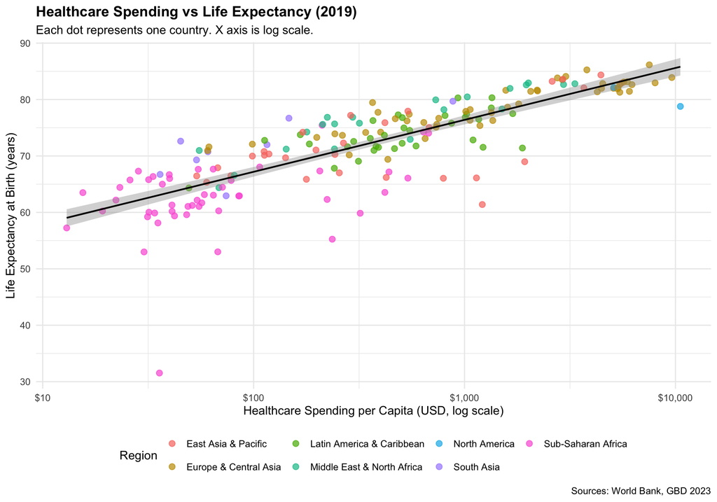

```r
df_2019 <- df %>%
  filter(year == 2019) %>%
  distinct(country, country_code, region,
           health_spending_per_capita, wb_life_expectancy)

ggplot(df_2019,
       aes(x = health_spending_per_capita,
           y = wb_life_expectancy,
           color = region)) +
  geom_point(alpha = 0.7, size = 2.5) +
  geom_smooth(method = "lm", se = TRUE,
              color = "black", linewidth = 0.8) +
  scale_x_log10(labels = dollar_format(prefix = "$")) +
  labs(
    title = "Healthcare Spending vs Life Expectancy (2019)",
    subtitle = "Each dot represents one country. X axis is log scale.",
    x = "Healthcare Spending per Capita (USD, log scale)",
    y = "Life Expectancy at Birth (years)",
    color = "Region",
    caption = "Sources: World Bank, GBD 2023"
  ) +
  theme_minimal(base_size = 12) +
  theme(plot.title = element_text(face = "bold"),
        legend.position = "bottom")
```

## 4.2 Disease Burden by Region

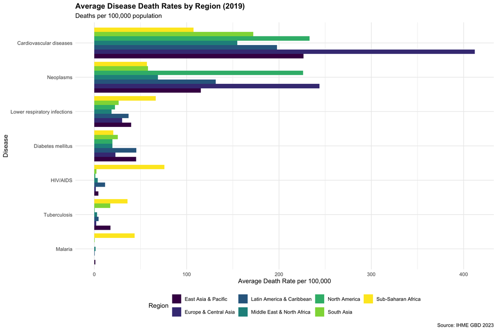

```r
df_disease_region <- df %>%
  filter(year == 2019, cause != "Total cancers") %>%
  group_by(region, cause) %>%
  summarise(avg_death_rate = mean(death_rate_per_100k, na.rm = TRUE),
            .groups = "drop")

ggplot(df_disease_region,
       aes(x = reorder(cause, avg_death_rate),
           y = avg_death_rate,
           fill = region)) +
  geom_col(position = "dodge") +
  coord_flip() +
  scale_fill_viridis_d() +
  labs(
    title = "Average Disease Death Rates by Region (2019)",
    subtitle = "Deaths per 100,000 population",
    x = "Disease",
    y = "Average Death Rate per 100,000",
    fill = "Region",
    caption = "Source: IHME GBD 2023"
  ) +
  theme_minimal(base_size = 11) +
  theme(plot.title = element_text(face = "bold"),
        legend.position = "bottom")
```

**Finding:** Cardiovascular disease is the leading cause of death across all regions, with Europe and Central Asia carrying a disproportionately high burden despite relatively high healthcare spending. Sub-Saharan Africa carries the highest burden of infectious diseases, particularly HIV/AIDS and Tuberculosis, while also having among the lowest healthcare spending globally. Malaria burden is almost entirely concentrated in Sub-Saharan Africa.

## 4.3 Does Healthcare Spending Reduce Disease Death Rates?

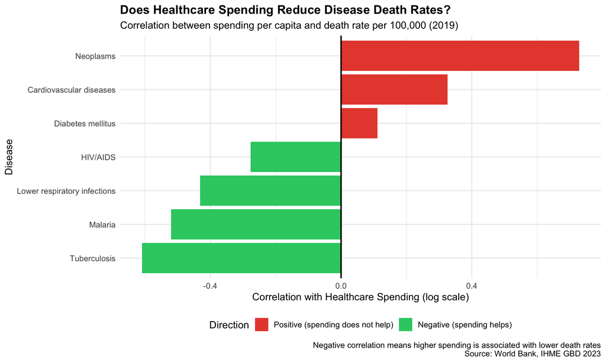

```r
df_corr <- df %>%
  filter(year == 2019, cause != "Total cancers",
         !is.na(death_rate_per_100k)) %>%
  group_by(cause) %>%
  summarise(
    correlation = cor(log10(health_spending_per_capita),
                      death_rate_per_100k,
                      use = "complete.obs"),
    n_countries = n(),
    .groups = "drop"
  ) %>%
  arrange(correlation)

ggplot(df_corr,
       aes(x = reorder(cause, correlation),
           y = correlation,
           fill = correlation < 0)) +
  geom_col() +
  coord_flip() +
  scale_fill_manual(
    values = c("TRUE" = "#2ecc71", "FALSE" = "#e74c3c"),
    labels = c("TRUE" = "Negative (spending helps)",
               "FALSE" = "Positive (spending does not help)")
  ) +
  geom_hline(yintercept = 0, linewidth = 0.8) +
  labs(
    title = "Does Healthcare Spending Reduce Disease Death Rates?",
    subtitle = "Correlation between spending per capita and death rate per 100,000 (2019)",
    x = "Disease",
    y = "Correlation with Healthcare Spending (log scale)",
    fill = "Direction",
    caption = "Negative correlation means higher spending is associated with lower death rates\nSource: World Bank, IHME GBD 2023"
  ) +
  theme_minimal(base_size = 12) +
  theme(plot.title = element_text(face = "bold"),
        legend.position = "bottom")
```

In contrast, non-communicable diseases, Neoplasms (cancer), Cardiovascular disease, and Diabetes, show positive correlations with spending. Higher-spending countries actually have higher reported death rates from these conditions. This is not because spending causes these diseases, but rather because wealthier, longer living populations are more exposed to lifestyle risk factors such as sedentary behavior, processed food consumption, and obesity, and they live long enough to develop these conditions.

This finding has direct implications for pharmaceutical R&D investment decisions: infectious disease burden is highly responsive to healthcare investment, while non-communicable disease burden requires addressing upstream lifestyle and demographic factors beyond healthcare spending alone.

## 4.4 Life Expectancy Trends by Region (2000 to 2019)

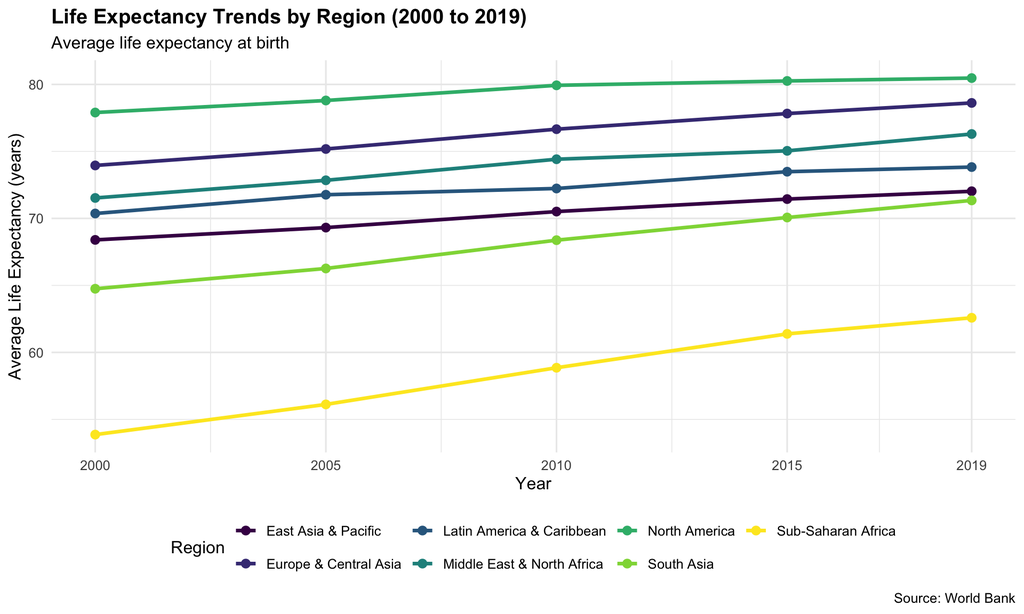

```r
df_trend <- df %>%
  distinct(country, country_code, region, year, wb_life_expectancy) %>%
  group_by(region, year) %>%
  summarise(avg_life_exp = mean(wb_life_expectancy, na.rm = TRUE),
            .groups = "drop")

ggplot(df_trend,
       aes(x = year, y = avg_life_exp,
           color = region, group = region)) +
  geom_line(linewidth = 1.2) +
  geom_point(size = 2.5) +
  scale_x_continuous(breaks = c(2000, 2005, 2010, 2015, 2019)) +
  scale_color_viridis_d() +
  labs(
    title = "Life Expectancy Trends by Region (2000 to 2019)",
    subtitle = "Average life expectancy at birth",
    x = "Year",
    y = "Average Life Expectancy (years)",
    color = "Region",
    caption = "Source: World Bank"
  ) +
  theme_minimal(base_size = 12) +
  theme(plot.title = element_text(face = "bold"),
        legend.position = "bottom")
```